# Grinding screen panel comparrison

Michael C. Smit

2020

# Summary

# Introduction

# Method

## Preparation (maybe include in design of experiment?)

Grinding Screens `321-SC-013` and `321-SC-014` were chosen for the comparison test. Ten `0.25 MTQ` panels were installed in `321-SC-014` on the $30^{th}$ of September.

`321-SC-013` was also fitted with relatively new `0.23 MT` screen panels. The oldest panels were installed 9th September.

## Sampling

Survey 1 was conducted while `Mill 2` was offline due to an issue with the mill liners. Survey 2 conducted with two secondary mills online but with higher than usual recirculating load. During the surveys, feed to the mills and recirculating load were steady for at least an hour.

Five (`5`) personnel were involved in obtaining the survey samples during each survey:

- One person took samples at the Primary Distributor, `DI-028`, that feeds the seven screen sets.
- Four personnel took overflow cuts from the individual screen decks’ lips using deep and wide rimmed plastic containers. care was given to cut streams entirely at constant speeds while ensuring no container overflow or spillage. Samples were simultaneously taken from both sides of individual screen decks by two personnel and then individual deck’s samples were combined.

Two sample cuts were taken from the feeds of `321-SC-013` and `321-SC-014`, as well as from the individual deck lip overflows.

Screen cluster feed and individual deck overflow samples were weighed, wet screened to get $-38 µm$ fractions, dried in the oven and sieved to determine the weight of each size fraction.

The following screens sizes were used ($\mu M$)

```
## sieves_used
##    0   38   53   75  106  150  180  212  300  425  600 1180
##    1    1    1    1    1    1    1    1    1    1    1    1
```

Each stream sample’s cummulative mass distribution function was modelled with two commonly used models in practise represent a vast variety of communution circuit products very well, namely the:

**Rosin-Rammler distribution** and  
**Gauss-Gaudin-Schumann distribution**.

The model that best fit each stream was selected with the aid of statistics. The modeled distribution functions ennabled more accurate interpolation of cumulative mass percentages.

# Model formulas

### Rosin Rammler (RR) Model:

The RR model distribution function has been used to describe the particle size distributions of various minerals, powders and liquids of various types and sizes. The function is particularly suited to represent those produced by grinding, milling, and crushing operations. The general expression of the RR model is:

$$\begin{equation}
F\left(d\right) = exp\left[-(\frac{d}{l})^{m} \right]
\label{eq : RR}
\end{equation}$$

where:  
$F(d)$ = distribution function (cum. passing)  
$d$ = particle size [mm]  
Parameters $\bar{d}$ and $m$ are adjustable parameters characteristic of the distribution.  
$\bar{d}$ = scale paramater (mean particle size [mm]) and = $\exp\left({-\frac{intercept}{slope}}\right)$.  
$m$ = slope paramater (measure of the spread of particle sizes).

The RR transformation is achieved by taking the natural log twice and simplified as:
$$\ln\left\{-\ln\left[1-F(d)\right] \right\} = m\times \ln d - m\times \ln \bar{d}$$
Note that the RR distribution transformation is conducted on the cummulative retained distribution (thus the $\left[1-F(d)\right]$.)

If a distribution plots a straight line after the above RR transformation, then the distrubution can be represented by the RR distribution function. This will alllow percentile interpolation according to the distribution and not a straight line between two points obatained from screening.

$$Y=mX + C$$

$$\underbrace{\ln\left\{-\ln\left[1-F(d)\right] \right\}}_\textrm{Y} = \underbrace{m}_\textrm{slope}\times \underbrace{\ln d}_\textrm{X}+\underbrace{ \left(-m\times \ln \bar{d}\right)}_\textrm{C}$$

#### Back-transformation

(This is really the reason why we’re doing the model fitting; so that we can better estimate the size at which a certain specified mass fraction will pass). The back-transform is then conducted to determine the required percentile values:

$$x = \bar{d} \left(- \ln \left(1-Y \right)\right)^\frac{1}{m}$$
$$size = scale parameter\times (-\ln (1-percentile))^{1/slope parameter}$$
, where the scale_parameter; is a function of the slope and intercept of the transf ormed RR model fit, as follows:
$$scale parameter = exp(-\frac{intercept}{slope} )$$

### Gates-Gaudin-Schumann (GGS) Model:

The Gates-Gaudin-Schumann plot is a graph of **cumulative % passing versus nominal sieve size**, with both the $X$ and $Y$ axes being logarithmic plots. In this type of plot, most of the data points (except for the two or three coarsest sizes measured) should lie nearly in a straight line.

$$y = F(x) = \left(\frac{x}{k}\right) ^n$$
or simmilarly: The above formula can be rewritten as: $x = k \times y ^ \frac{1}{n}$

where:  
$y$ = $F \left(x\right)$ = cumulative undersize distribution function.  
$x$ = particle size,  
$k$ = maximum particle size of the transformed straight line corresponding to $100%$ cum. passing.

Log transformation of the distribution yields:

$$\ln y = n \ln x - n \ln k$$

Applying this transformation to the measured observed distribution data points will yield near straight lines if the data fits the model, and interpolation on along a straight line is much easier than along the curved arithmetic distribution function.

If the size distribution of particles from a crushing or grinding operation does not approximate a straight line, it suggests that there may have been a problem with the data collection, or there is something unusual happening in the comminution process. The size modulus is a measure of how coarse the size distribution is, and the distribution modulus is a measure of how broad the size distribution is. Size modulus for a size distribution can be determined from a graph by extrapolating the straight-line portion up to 100% passing and finding the corresponding size value. The distribution modulus can be calculated by choosing two points in the linear portion of the graph, calculating the logs of the sizes and % passing values, and calculating the slope.

# Results and Discussion

Each test’s feed stream PSD results were first compared to confirm that their distributions were simmilar to allow for comparitive statictics.

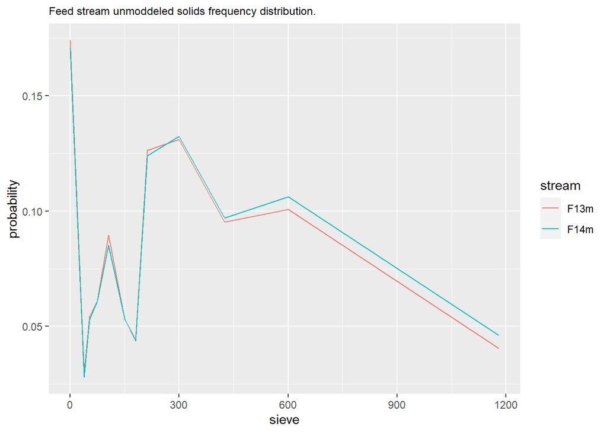

The two most commmonly used distributions in Geology and Mineral Processing and specifically comminution circuits are the Roslin-Rammler and the Gates-Gaudin-Schumann distributions.

Both models were used to model all PSD screening data to, and the subsequent best fit model was selected in each case. Model selection was determined by comparing each PSD’s transformed linear model’s determinant ($R^2$). Interpolation betweeen measured sizing points is conducted by the back-transformation of the model-fitted points along the respective model’s distribution function.